# Exercise Method Prediction

Gueller

7/18/2020

### Overview

In this assignment, we will use data collected as part of a Human Activity Recognition (HAR) study and machine learning to determine how effective the data collected is for prediction of the quality of the exercise activity.

The activity is “Unilaterial Dumbbell Biceps Curl”. Each participant was asked to perform 10 repetitions, 5 different methods. Essentially, one method was correct, the other four were incorrect in a prescribed manner. The manner in which the activity was completed is captured in the “classe” field; the meaning of the categorizations is shown in the appendix.

### Setting the Environment

```r
knitr::opts_chunk$set(echo=FALSE)
# Always set the seed
set.seed(1994)
# Libraries
library(caret)
library(rpart)
library(rattle)
library(randomForest)
library(knitr)
library(corrplot)
library(RColorBrewer)
library(kableExtra)
```

### Loading, Cleaning and Arranging the Data

```r
# locations of the data
trainURL <- "https://d396qusza40orc.cloudfront.net/predmachlearn/pml-training.csv"
testURL <- "https://d396qusza40orc.cloudfront.net/predmachlearn/pml-testing.csv"

# read the data in
training <- read.csv(url(trainURL))
testing <- read.csv(url(testURL))
dim(testing)
```

```
## [1]  20 160
```

We will be working with the training set for now, holding out the testing set for the quiz.

Exploration of the data set using head (not shown here) revealed that the first 7 columns of the data are identifiers that will be removed. Using the is.na function revealed that a number of the fields were almost entirely NA, and those will be removed as well.

```r
# Remove Identifiers
training <- training[,-(1:7)]
dim(training)
```

```
## [1] 19622   153
```

```r
# Remvove NA's
remNA <- sapply(training, function(x) mean(is.na(x))) > 0.975
training <- training[,remNA==FALSE]
dim(training)
```

```
## [1] 19622    86
```

The near zero variance variables will be identified and removed.

```r
nearZero <- nearZeroVar(training)
# nearZero
training <- training[,-nearZero]
dim(training)
```

```
## [1] 19622    53
```

```r
# Break the training set into training and test
inTrain <-createDataPartition(training$classe, p=0.7, list=FALSE)
trainSet <- training[inTrain,]
testSet <- training[-inTrain,]
dim(trainSet);dim(testSet)
```

```
## [1] 13737    53
```

```
## [1] 5885   53
```

```r
# set classe as.factor
trainSet$classe <- as.factor(trainSet$classe)
testSet$classe <- as.factor(testSet$classe)
levels(trainSet$classe);levels(testSet$classe)
```

```
## [1] "A" "B" "C" "D" "E"
```

```
## [1] "A" "B" "C" "D" "E"
```

### Correlation Analysis

We will look at the number of highly correlated variables to see if a Principal Component Analysis should be done.

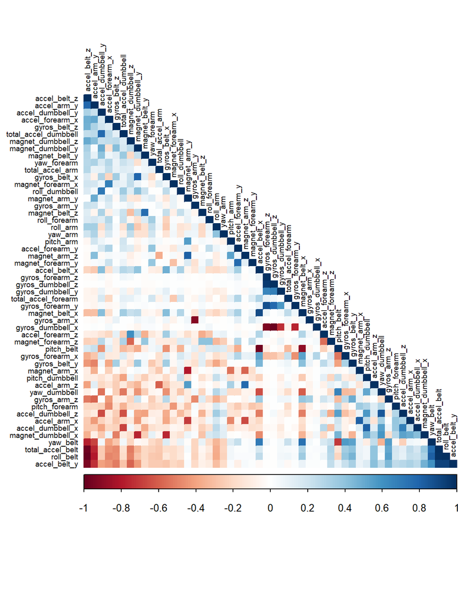

```r
correlationMatrix <- cor(trainSet[,-53])
corrplot(correlationMatrix, order="FPC", method="color", type="lower",
    tl.cex=0.6, tl.col=rgb(0,0,0))
```

From the graph, there appears to be a number of $^+_-$highly correlated variables. If PCA is performed, interpretability will be lost and will not be performed. PCA could be explored if scalability of the select model becomes necessary.

## Decision Tree

[figure not shown]

```r
mdl_dt <- rpart(classe~., data=trainSet, method="class")
fancyRpartPlot(mdl_dt, main="Decision Tree", sub="", palettes=c("Reds", "Greys"))
```

```r
prd_dt <- predict(mdl_dt, newdata=testSet, type="class")
cm_dt <- confusionMatrix(prd_dt, testSet$classe)
acc_dt <- round(cm_dt$overall['Accuracy'],4)
kap_dt <- round(cm_dt$overall['Kappa'],4)
```

## Random Forest

```r
set.seed(1994)
ctrl_rf <- trainControl(method="cv", number=3, verboseIter=FALSE)
mdl_rf <- train(classe~., data=trainSet, method="rf",
    trControl=ctrl_rf)
mdl_rf$finalModel
```

```
##
## Call:
##  randomForest(x = x, y = y, mtry = param$mtry)
##                Type of random forest: classification
##                      Number of trees: 500
## No. of variables tried at each split: 27
##
##         OOB estimate of  error rate: 0.68%
## Confusion matrix:
##      A    B    C    D    E class.error
## A 3897    6    2    0    1 0.002304147
## B   18 2635    5    0    0 0.008653123
## C    0   14 2372   10    0 0.010016694
## D    0    0   22 2228    2 0.010657194
## E    0    2    5    7 2511 0.005544554
```

```r
prd_rf <- predict(mdl_rf, newdata=testSet)
cm_rf <- confusionMatrix(prd_rf, testSet$classe)
cm_rf
```

```
## Confusion Matrix and Statistics
##
##           Reference
## Prediction    A    B    C    D    E
##          A 1671   13    0    0    0
##          B    0 1125    8    0    0
##          C    2    1 1015   11    2
##          D    0    0    3  951    1
##          E    1    0    0    2 1079
##
## Overall Statistics
##
##                Accuracy : 0.9925
##                  95% CI : (0.99, 0.9946)
##     No Information Rate : 0.2845
##     P-Value [Acc > NIR] : < 2.2e-16
##
##                   Kappa : 0.9905
##
##  Mcnemar's Test P-Value : NA
##
## Statistics by Class:
##
##                      Class: A Class: B Class: C Class: D Class: E
## Sensitivity            0.9982   0.9877   0.9893   0.9865   0.9972
## Specificity            0.9969   0.9983   0.9967   0.9992   0.9994
## Pos Pred Value         0.9923   0.9929   0.9845   0.9958   0.9972
## Neg Pred Value         0.9993   0.9971   0.9977   0.9974   0.9994
## Prevalence             0.2845   0.1935   0.1743   0.1638   0.1839
## Detection Rate         0.2839   0.1912   0.1725   0.1616   0.1833
## Detection Prevalence   0.2862   0.1925   0.1752   0.1623   0.1839
## Balanced Accuracy      0.9976   0.9930   0.9930   0.9929   0.9983
```

```r
acc_rf <- round(cm_rf$overall['Accuracy'],4)
kap_rf <- round(cm_rf$overall['Kappa'],4)
```

## Generalized Boosted Method

```r
set.seed(1994)
ctrl_gbm <- trainControl(method="repeatedcv", number=5, repeats=1)
mdl_gbm <- train(classe~., data=trainSet, method="gbm",
    trControl=ctrl_gbm, verbose=FALSE)
mdl_gbm$finalModel
```

```
## A gradient boosted model with multinomial loss function.
## 150 iterations were performed.
## There were 52 predictors of which 52 had non-zero influence.
```

```r
prd_gbm <- predict(mdl_gbm, newdata=testSet)
cm_gbm <- confusionMatrix(prd_gbm, testSet$classe)
cm_gbm
```

```
## Confusion Matrix and Statistics
##
##           Reference
## Prediction    A    B    C    D    E
##          A 1643   40    0    0    0
##          B   15 1077   44    7    5
##          C    7   20  971   28    5
##          D    8    2    9  921   15
##          E    1    0    2    8 1057
##
## Overall Statistics
##
##                Accuracy : 0.9633
##                  95% CI : (0.9582, 0.968)
##     No Information Rate : 0.2845
##     P-Value [Acc > NIR] : < 2.2e-16
##
##                   Kappa : 0.9536
##
##  Mcnemar's Test P-Value : 1.163e-08
##
## Statistics by Class:
##
##                      Class: A Class: B Class: C Class: D Class: E
## Sensitivity            0.9815   0.9456   0.9464   0.9554   0.9769
## Specificity            0.9905   0.9850   0.9877   0.9931   0.9977
## Pos Pred Value         0.9762   0.9382   0.9418   0.9644   0.9897
## Neg Pred Value         0.9926   0.9869   0.9887   0.9913   0.9948
## Prevalence             0.2845   0.1935   0.1743   0.1638   0.1839
## Detection Rate         0.2792   0.1830   0.1650   0.1565   0.1796
## Detection Prevalence   0.2860   0.1951   0.1752   0.1623   0.1815
## Balanced Accuracy      0.9860   0.9653   0.9670   0.9742   0.9873
```

```r
acc_gbm <- round(cm_gbm$overall['Accuracy'],4)
kap_gbm <- round(cm_gbm$overall['Kappa'],4)
```

### Results

```r
result_dt <- as.data.frame(rbind(c(acc_dt,kap_dt)))
result_rf <- as.data.frame(rbind(c(acc_rf,kap_rf)))
result_gbm <- as.data.frame(rbind(c(acc_gbm,kap_gbm)))
tab <- rbind(result_dt, result_rf, result_gbm)
row.names(tab) <- c("Decision Tree", "Random Forest", "Generalized Boosted Method")
# Pretty output
kable(tab, "latex", caption="Results") %>%
    kable_styling(full_width=FALSE, position="left",
        latex_options="striped", stripe_index=c(2),
        stripe_color = "yellow")
```

[output not shown]

### Appendix

Overview Information:

- http://groupware.les.inf.puc-rio.br/har
- Velloso, E.; Bulling, A.; Gellersen, H.; Ugulino, W.; Fuks, H. Qualitative Activity Recognition of Weight Lifting Exercises. Proceedings of 4th International Conference in Cooperation with SIGCHI (Augmented Human ’13) . Stuttgart, Germany: ACM SIGCHI, 2013.

Dataset provided by Instructor taken from:

- http://web.archive.org/web/20161224072740/http:/groupware.les.inf.puc-rio.br/har

Visualization

- The Classe decision tree was plotted using the R Rattle package.

“classe”

Class A - Exactly according to the specification

Class B - Throwing the elbows to the front

Class C - Lifting the dumbbell only halfway

Class D - Lowering the dumbbell only halfway Class E - Throwing the hips to the front